# Problem Set 03

Due Friday, October 7, 2016

## Tips

- Knit this file once first to read the questions.
- Remember, pictures are worth a thousand words. Your responses should be a combination of written analysis/interpretation and graphics.
- You will need to use Google a little to learn some background and for investigations, as any good data scientist would.
- **I can’t emphasize this enough**: Look at and explore your data with the `View()` command and
  - play with the Filter button
  - sort each variable in increasing and decreasing order by clicking the arrow next to the variable name
- The above was a mantra on my analyst team at Google: Always stay close to your data.

```r
# Do not modify any code in this block. You need to run it once in your console
# to load all the necessary packages, but do not change anything.
library(ggplot2)
library(dplyr)
library(Quandl)
library(lubridate)
Quandl.api_key("izVwTt9m5VoEe7TsEzdr")
```

## Question 1: Bitcoin and Gold

Imagine you are working for a foreign exchange company. You are presented with a data set `currencies` (which is loaded in the code block) below, which consists of data on two forms of tradable currency: bitcoin and gold. Give these pages a read:

- [Bitcoin](https://www.quandl.com/data/BAVERAGE/USD)
- [Gold](https://www.quandl.com/data/BUNDESBANK/BBK01_WT5511)

```r
bitcoin <-
  Quandl("BAVERAGE/USD", start_date="2013-01-01", end_date="2016-01-01") %>%
  mutate(type="bitcoin", date=ymd(Date)) %>%
  rename(price=`24h Average`) %>%
  select(type, date, price)

# Get gold data off quandl.com
gold <-
  Quandl("BUNDESBANK/BBK01_WT5511", start_date="2013-01-01", end_date="2016-01-01") %>%
  mutate(type="gold", date=ymd(Date)) %>%
  rename(price=Value) %>%
  select(type, date, price)

# Combine bitcoin and gold data frames into a single one: currencies
currencies <- bind_rows(bitcoin, gold) %>%
  group_by(type) %>%
  arrange(type, date) %>%
  mutate(percent_diff = 100*(price-lag(price))/lag(price)) %>%
  tbl_df()
```

#### a)

Your boss wants to know: “You took Intro to Statistical and Data Sciences right? Give me an executive summary of trends in these two forms of currency.”

**Solution**: Overall, while gold seems to be trending down, it is much more stable and fluctuates less. Bitcoin has definitely not recovered from its peak value in late 2013. In fact, on November 19, 2013, the value of a bitcoin on the Mt. Gox exchange soared after a United States Senate committee hearing was told by the FBI that virtual currencies are a legitimate financial service.

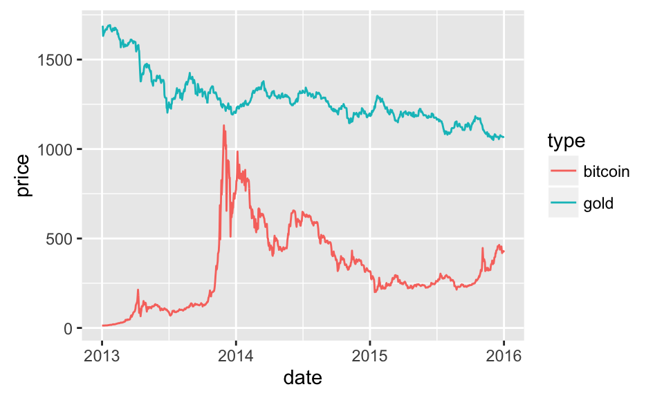

```r
# Write your code below:
ggplot(data=currencies, aes(x=date, y=price, col=type)) +
  geom_line()
```

#### b)

Your boss wants to know: “So we got an investor who has no stomach for volatility in currency prices; they like a nice stable currency to park their money in and not worry about it. What should they invest in?”

**Solution**: the variable `percent_diff` really highlights this trend. It is clear that gold is wayyyyyy less volatile than bitcoin. i.e. invest in bitcoin only if you have the stomach for it.

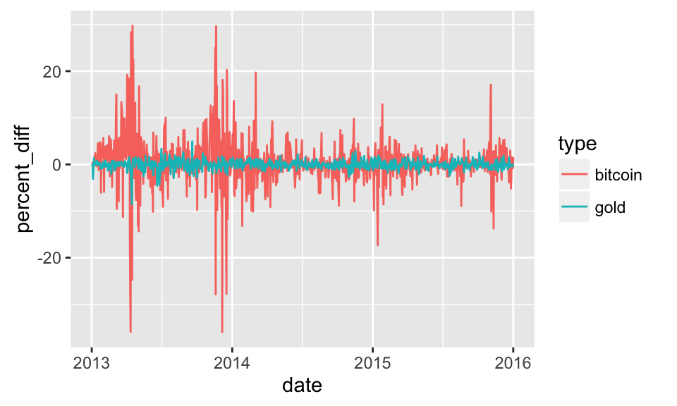

```r
# Write your code below:
ggplot(data=currencies, aes(x=date, y=percent_diff, col=type)) +
  geom_line()
```

`percent_diff` is computed as follows:

$$\text{% difference} = \frac{\text{Price Today} - \text{Price Yesterday}}{\text{Price Yesterday}} \times 100 \%$$

i.e. you follow these steps:

- take the **absolute difference/change** in price $\text{Price Today} - \text{Price Yesterday}$
- **rescale** it by dividing by the original price $\text{Price Yesterday}$
- then convert to a percentage

#### STOP

And observe. It is now the start of week 6, and only now do we see our first formula. Recall the choice we took for this intro-level class:

If we’re going to remove this…

We need this to fill the void…

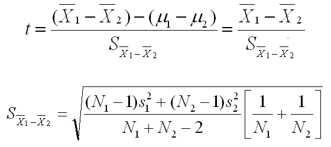

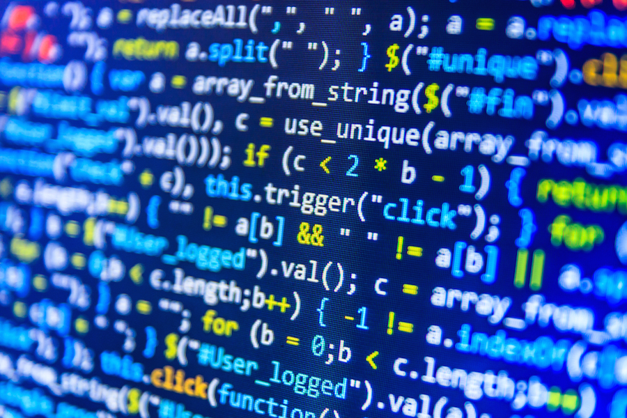

This emphasizes another important point:

- **statistics is not math**
- **statistics uses math** as a tool to answer questions about the world using data, like in physics/econ/bio.

#### c)

Your boss wants to know: “What day did bitcoin lose the most value in one day? What was a possible cause?”

**Solution**: Running `View(currencies)` and then sorting by `perc_diff` we see that on December 6, 2013 lost 35.96% of its value **in one day**.

Let’s use a popular search engine called Google to investigate. If you search “bitcoin december 2013”, one of the links is [this](http://www.fool.com/investing/general/2013/12/21/what-made-the-december-bitcoin-crash-different.aspx).

## Question 2: Cheese and Milk Production

Imagine you are working for the US Department of Agriculture. You want to compare milk and cheese production in the United States since 1925 using the following data:

- [Cheese](https://www.quandl.com/data/USDANASS/NASS_CHEESEPRODUCTIONMEASUREDINLB)
- [Milk](https://www.quandl.com/data/NASS_MILKPRODUCTIONMEASUREDINLB)

```r
# Get cheese data off quandl.com
cheese <-
  Quandl("USDANASS/NASS_CHEESEPRODUCTIONMEASUREDINLB", start_date="1925-01-01") %>%
  mutate(type="cheese", date=ymd(Date), value=Value) %>%
  select(type, date, value)

# Get milk data off quandl.com
milk <-
  Quandl("USDANASS/NASS_MILKPRODUCTIONMEASUREDINLB", start_date="1925-01-01") %>%
  mutate(type="milk", date=ymd(Date), value=Value) %>%
  select(type, date, value)

# Combine cheese and milk into a single one
food <- bind_rows(cheese, milk) %>%
  tbl_df()
```

#### a)

Between cheese and milk, relatively speaking, which agricultural good has seen the bigger overall increases in production?

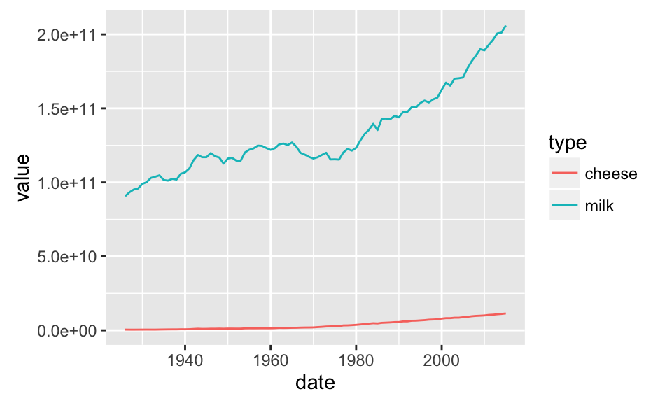

```r
# Write your code below:
ggplot(data=food, aes(x=date, y=value, col=type)) +
  geom_line()
```

**Solution**: At first glance, it seems milk made the biggest gains!

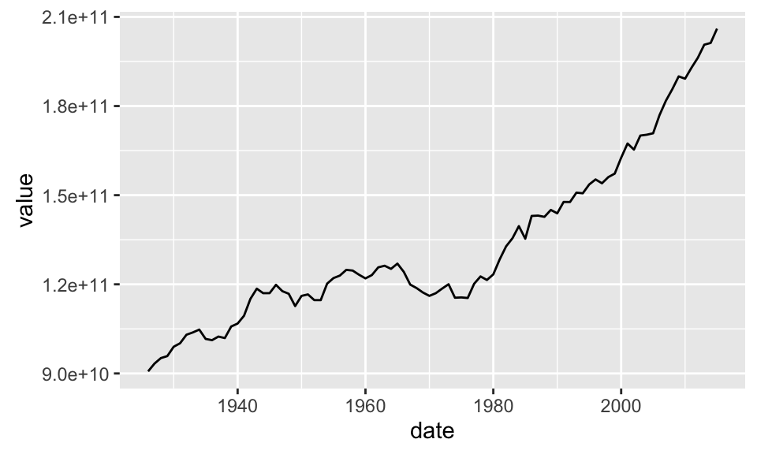

```r
# Write your code below:
ggplot(data=milk, aes(x=date, y=value)) +
  geom_line()
```

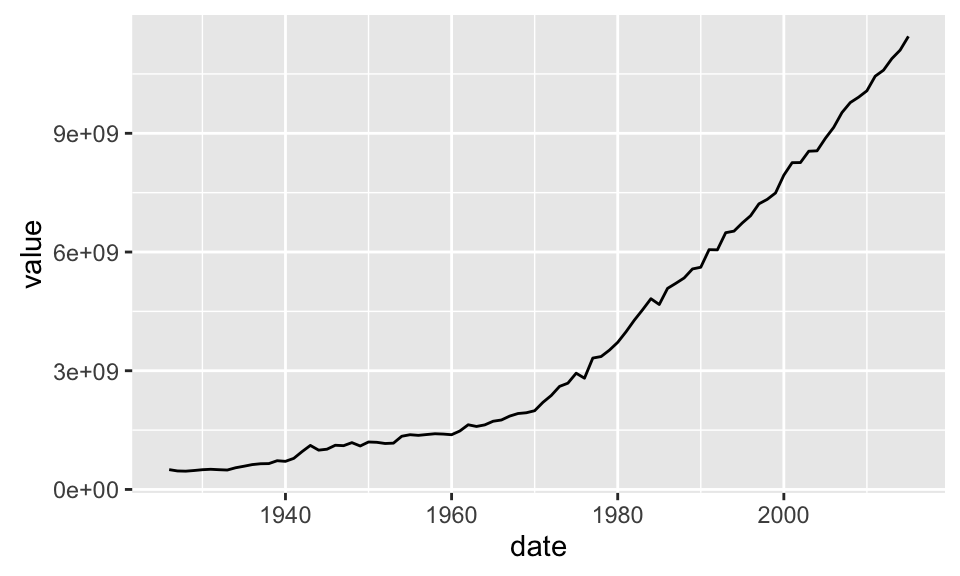

```r
ggplot(data=cheese, aes(x=date, y=value)) +
  geom_line()
```

Both trend up, but which had the biggest relative increases i.e. which had the **highest percent increase**?

| Food Type | 1925 | 2014 | Absolute Change | % Change |
| --- | --- | --- | --- | --- |
| milk | 90,699,000,000 | 206,046,000,000 | 115,347,000,000 | 127.18% |
| cheese | 501,096,000 | 11,450,117,000 | 10,949,021,000 | 2185.01% |

Cheese wins by a landslide. 2100% increase.